# Spectral Fst on F model with 3 populations

Clement Gain

2021-04-23

This vignette aims at showing some results presented in the paper “A Spectral Theory for Wright’s Inbreeding Coefficients and Related Quantities”, in particular with datas coming from a F model with 3 populations. There are several steps in this vignette : * Simulation of the datas using F model with 3 populations * Computing the average value of Wright’s FST over all loci included in the genotype matrix using Wright’s formula (this can be computed using the package function **mean_wright_fst** ) * Computing the average value of Wright’s FST over all loci included in the genotype matrix using the squared norm of the between population matrix Zst (this can be computed using the package function **compute_partition**) * Computing several quantities of interests * scree plot anf projection of PCA from matrix Z, Zs and Zst

The only required package is *spectral_fst*

```r
library(spectralfst)
```

## Data simulation

Here, we use a F model with 3 populations to simulate our datas.

```r
## parameters F model
F1 = 0.3
F2 = 0.2
F3 = 0.1

L = 20000
n = 150
c = c(1/3,1/3,1/3)


# genotype matrices
X <- matrix(NA, nrow = n, ncol = L)
n1 <- round(n*c[1])
n2 <- round(n*c[2])
n3 <- n - n1 - n2


for (l in 1:L){
  p <- runif(1)
  p1 <- rbeta(1, p*(1-F1)/F1, (1-p)*(1-F1)/F1)
  p2 <- rbeta(1, p*(1-F2)/F2, (1-p)*(1-F2)/F2)
  p3 <- rbeta(1, p*(1-F3)/F3, (1-p)*(1-F3)/F3)
  X[1:n1,l] <- rbinom(n1, size = 1, prob = p1)
  X[(n1+1):(n1+n2),l] <- rbinom(n2, size = 1, prob = p2)
  X[(n1+n2+1):n,l] <- rbinom(n3, size = 1, prob = p3)
}

## SNPs filtering
boo.unique <- apply(X, 2, FUN = function(x) length(unique(x))) == 1
X <- X[,!boo.unique]
L <- ncol(X)

# Population_assignment vector creation

pop <- c(rep(1,n1), rep(2,n2), rep(3,n3))
```

```r
dim(X)
```

```
#> [1]   150 18891
```

## Average value of Wright’s FST

We’re going to compute average value of wright’s Fst using the formula :

```r
fst_wright <- mean_wright_fst(X, pop)
print("Wright's formula gives a mean fst of : ")
```

```
#> [1] "Wright's formula gives a mean fst of : "
```

```r
fst_wright
```

```
#> [1] 0.1331801
```

and using the spectral theory, more specifically using the squared norm of the between population matrix

```r
spectral_fst <- compute_partition(X, pop)
print("Fst compute with between population matrix Zst")
```

```
#> [1] "Fst compute with between population matrix Zst"
```

```r
spectral_fst$Fst
```

```
#> [1] 0.1331801
```

Those 2 values are strictly equal and will be equal for any case

## Related quantities

We can obtain a Fst approximation by computing the centered scaled PCA of genotype matrix

```r
print("Fst approximation using Z matrix")
```

```
#> [1] "Fst approximation using Z matrix"
```

```r
spectral_fst$Fst_approximation
```

```
#> [1] 0.1332569
```

We also can obtain the leading eigenvalue of Zs matrix

```r
print("The leading eigenvalue of Zs matrix is :")
```

```
#> [1] "The leading eigenvalue of Zs matrix is :"
```

```r
spectral_fst$leadingeigenZs
```

```
#> [1] 0.008071197
```

```r
print("The RMT prediction of the leading eigenvalue of Zs is : ")
```

```
#> [1] "The RMT prediction of the leading eigenvalue of Zs is : "
```

```r
spectral_fst$RMTprediction
```

```
#> [1] 0.006982953
```

## PC plots of Z, Zs and Zst

For Z (i.e genotype) matrix

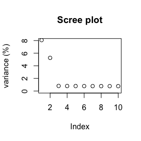

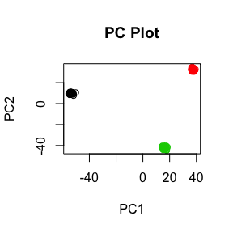

```r
plot(spectral_fst$eigenZ[1:10] * 100, ylab="variance (%)", main="Scree plot", ylim=c(0,8))
plot(spectral_fst$pcZ, col = pop, main="PC Plot")
```

For Zst matrix :

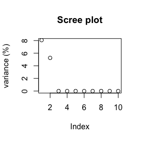

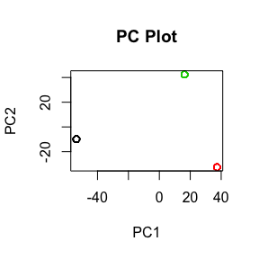

```r
plot(spectral_fst$eigenZst[1:10] * 100, ylab="variance (%)", main="Scree plot", ylim=c(0,8))
plot(spectral_fst$pcZst, col = pop, main="PC Plot")
```

It is important to notice that in the case of Fmodel, these plots are really close

For Zs matrix :

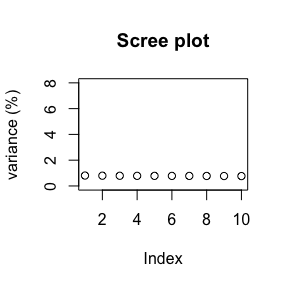

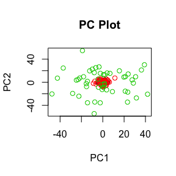

```r
plot(spectral_fst$eigenZs[1:10] * 100, ylab="variance (%)", main="Scree plot", ylim=c(0,8))
plot(spectral_fst$pcZs, col = pop, main="PC Plot")
```